# Python for Data Science - End Sem Exam - Total - 100 Marks

### Q3a. Write a Python program that takes a list of integers as input and returns a new list containing only the prime numbers that are also palindromes (e.g., 131, 7, 11). If no such numbers are found, return an empty list. (8 Marks)

```python
def is_prime(n):
    if n < 2:
        return False
    for i in range(2, int(n**0.5)+1):
        if n % i == 0:
            return False
    return True

def is_palindrome(n):
    return str(n) == str(n)[::-1]

def prime_palindromes(nums):
    return [num for num in nums if is_prime(num) and is_palindrome(num)]

# Example
nums = [7, 11, 121, 131, 23, 101]
print(prime_palindromes(nums))  # Output: [7, 11, 131, 101]
```

```
[7, 11, 131, 101]
```

Explanation:

is_prime() checks primality.

is_palindrome() checks if number reads same forward/backward.

List comprehension filters numbers satisfying both.

### Q3b. Write a Python program to manage a basic student marks system. Your program should:(8 Marks)

1.Allow the user to add a new student with their name and marks.

2.Implement a function to update the marks of an existing student.

3.Implement a function to calculate the average marks of all students.

4.Implement a function to display all student names with their marks.

```python
students = {}

def add_student(name, marks):
    students[name] = marks

def update_marks(name, marks):
    if name in students:
        students[name] = marks
    else:
        print("Student not found!")

def average_marks():
    return sum(students.values()) / len(students) if students else 0

def display_students():
    for name, marks in students.items():
        print(f"{name}: {marks}")

# Example usage
add_student("Alice", 85)
add_student("Bob", 90)
update_marks("Alice", 95)
print("Average:", average_marks())
display_students()
```

```
Average: 92.5
Alice: 95
Bob: 90
```

Explanation:

Dictionary stores student → marks.

Functions handle CRUD operations.

Average calculated using sum()/len().

### Q3c. Create a Python function that takes a dictionary of employee names with their corresponding (years of experience, base bonus, and performance rating on a scale of 1–5). The function should calculate and return a new dictionary with adjusted bonuses based on the following rules:(8 Marks)

If an employee has more than 10 years of experience, increase their bonus by 20% plus 3% of the base bonus multiplied by their performance rating.

If they have between 5 and 10 years of experience, increase their bonus by 15% plus 2% of the base bonus multiplied by their performance rating.

If they have less than 5 years of experience, increase their bonus by 10% plus 1% of the base bonus multiplied by their performance rating.

The function should return a new dictionary with employee names and their updated bonus amounts.

Example:

Input:

employees = { "Raju": (12, 3000, 4), "Somu": (8, 2500, 3), "Ravi": (3, 2000, 5), "David": (15, 4000, 2) }

Output:

Adjusted salaries: Raju: $3960.0, Somu: $3025.0, Ravi: $2300.0, David: $5040.0

Problem: Adjust bonuses based on experience and performance rating.

Code:

```python
def calculate_bonus(employees):
    updated = {}
    for name, (years, base_bonus, rating) in employees.items():
        if years > 10:
            bonus = base_bonus * (1.20 + 0.03 * rating)
        elif 5 <= years <= 10:
            bonus = base_bonus * (1.15 + 0.02 * rating)
        else:
            bonus = base_bonus * (1.10 + 0.01 * rating)
        updated[name] = round(bonus, 2)
    return updated

# Example
employees = {
    "John": (12, 10000, 4),
    "Mary": (7, 8000, 5),
    "Sam": (3, 5000, 2)
}
print(calculate_bonus(employees))
```

```
{'John': 13200.0, 'Mary': 10000.0, 'Sam': 5600.0}
```

Explanation:

Rules applied with conditional logic.

Multipliers adjust base bonus.

Rounded for neatness.

### Q3d. Write a Python program that takes a list of sentences and returns a dictionary where the keys are the unique words (case insensitive) that are at least 4 characters long, and the values are the counts of those words. Ignore punctuation and consider only alphabetic characters. (8 marks)

Example:

Input:

sentences = [ "The quick brown fox jumps over the lazy dog.", "Is this the real life? It is just fantastic!", "And in the end, the love you take is equal to the hate you make.", "To be or not to be, that is the question." ]

Output:

Word frequency (length >= 4): {'quick': 1, 'brown': 1, 'jumps': 1, 'over': 1, 'lazy': 1, 'this': 1, 'real': 1, 'life': 1, 'just': 1, 'fantastic': 1, 'love': 1, 'take': 1, 'equal': 1, 'hate': 1, 'make': 1, 'that': 1, 'question': 1}

Problem: From sentences, count unique words ≥4 characters, case-insensitive, ignoring punctuation.

```python
import re

def word_count(sentences):
    word_dict = {}
    for sentence in sentences:
        words = re.findall(r"[a-zA-Z]+", sentence.lower())
        for word in words:
            if len(word) >= 4:
                word_dict[word] = word_dict.get(word, 0) + 1
    return word_dict

# Example
sentences = ["Python is great!", "Programming in Python is fun.", "Fun with coding."]
print(word_count(sentences))
```

```
{'python': 2, 'great': 1, 'programming': 1, 'with': 1, 'coding': 1}
```

Explanation:

Regex extracts alphabetic words.

Converted to lowercase for case-insensitivity.

Dictionary counts words ≥4 characters.

### Q3e. Given two lists containing the names of students and their respective dates of birth (in the format "YYYY-MM-DD"), write a Python program to answer the following:

a) Print the name of the student who is the youngest. (4 marks)

b) Print the names of students who were born in the month of December. (4 marks)

note: names = ["Alice", "Bob", "Charlie", "Diana", "Eve"] birthdays = ["2005-06-15", "2003-12-22", "2004-05-10", "2006-12-05", "2003-01-11"]

Q3 (e) Students’ DOB Analysis Problem: Given names + DOBs, find youngest student and those born in December.

Code:

```python
from datetime import datetime

def analyze_dobs(names, dobs):
    dob_dict = {name: datetime.strptime(dob, "%Y-%m-%d") for name, dob in zip(names, dobs)}

    # Youngest student
    youngest = max(dob_dict, key=dob_dict.get)
    print("Youngest student:", youngest)

    # Students born in December
    december_students = [name for name, dob in dob_dict.items() if dob.month == 12]
    print("Born in December:", december_students)

# Example
names = ["Alice", "Bob", "Charlie"]
dobs = ["2000-12-15", "1999-05-20", "2001-12-01"]
analyze_dobs(names, dobs)
```

```
Youngest student: Charlie
Born in December: ['Alice', 'Charlie']
```

Explanation:

datetime.strptime parses DOBs.

max() finds latest date → youngest.

Month check (dob.month == 12) filters December births.

## SECTION C - 40 Marks

## 4. Load the dataset and perform the below operation

### 4 a)

(i) Load the dataset and find the number of cars with a price greater than $25,000. Calculate the average mileage for these cars. Write your inference. (4 Marks)

(ii) You are analyzing car pricing based on fuel type. Separate the data into Petrol and Diesel cars. Compute the average price for each group and print the results. (5 Marks)

(iii) As a data analyst for a car dealership, summarize the inventory by make: calculate the average price and the maximum mileage for each brand. (3 Marks)

(iv) Add a new column named Mileage Category to classify cars into 'Low', 'Moderate', and 'High' based on their mileage ranges:

0 < Mileage < 30,000 → Low

30,000 < Mileage < 100,000 → Moderate

Mileage > 100,000 → High (4 Marks)

(v) As a pricing analyst, identify the highest-priced car available for every make in your dealership’s inventory. (4 Marks)

Q4 (a) Car Pricing & Mileage Analysis (i) Cars with price > 25,000 and average mileage

```python
import pandas as pd

df = pd.read_csv("car_info.csv")

# Cars with price > 25,000
high_price_cars = df[df["Price"] > 25000]
count_high_price = len(high_price_cars)
avg_mileage_high_price = high_price_cars["Mileage"].mean()

print("Number of cars with price > 25,000:", count_high_price)
print("Average mileage of these cars:", avg_mileage_high_price)
```

```
Number of cars with price > 25,000: 817
Average mileage of these cars: 102003.55201958385
```

Inference:

This tells us how many premium cars are in inventory.

Average mileage helps understand whether high-priced cars are newer (low mileage) or older (high mileage).

```python
# (ii) Average price by fuel type
avg_price_by_fuel = df.groupby("Fuel_Type")["Price"].mean()
print(avg_price_by_fuel)
```

```
Fuel_Type
Diesel    53863.204365
Petrol    53188.651210
Name: Price, dtype: float64
```

Inference:

Compare Petrol vs Diesel average prices.

Useful for dealership pricing strategy.

```python
# (iii) Inventory summary by make

summary = df.groupby("Make").agg(
    avg_price=("Price", "mean"),
    max_mileage=("Mileage", "max")
)
print(summary)
```

```
               avg_price  max_mileage
Make
Audi        52472.989362       198393
BMW         54302.551402       196458
Chevrolet   49898.934579       199893
Ford        58432.390909       199652
Honda       53619.518072       196425
Hyundai     60842.516484       199700
Mercedes    52823.489583       197103
Nissan      51360.670213       199100
Toyota      52706.525424       196238
Volkswagen  49136.260000       199568
```

Inference:

Shows brand-level performance.

Helps identify which brands have higher mileage cars (older stock).

```python
# (iv) Mileage Category classification

def mileage_category(m):
    if m < 30000:
        return "Low"
    elif m < 100000:
        return "Moderate"
    else:
        return "High"

df["Mileage_Category"] = df["Mileage"].apply(mileage_category)
print(df[["Make","Mileage","Mileage_Category"]].head())
```

```
         Make  Mileage Mileage_Category
0        Audi   147011             High
1      Nissan     1781              Low
2  Volkswagen   115586             High
3         BMW   188772             High
4        Audi    28624              Low
```

Inference:

Categorizes cars into usage levels.

Useful for customer segmentation (new vs used buyers).

```python
# (v) Highest-priced car per make
highest_price_per_make = df.groupby("Make").apply(lambda x: x.loc[x["Price"].idxmax()])
print(highest_price_per_make[["Make","Model","Price"]])
```

```
                  Make    Model  Price
Make
Audi              Audi  Model B  99862
BMW                BMW  Model C  99863
Chevrolet    Chevrolet  Model A  99353
Ford              Ford  Model A  99385
Honda            Honda  Model A  98150
Hyundai        Hyundai  Model D  98646
Mercedes      Mercedes  Model D  99044
Nissan          Nissan  Model E  99156
Toyota          Toyota  Model B  99962
Volkswagen  Volkswagen  Model B  98992
```

## 4 b)

(i) Create a boxplot to show the distribution of car prices for each brand (Make), grouped by fuel type (Fuel_Type). Add an appropriate title. (4 marks)

(ii) How can we calculate the average price for each car make while filtering out listings with missing values in the Price or Mileage columns. (4 Marks)

(iii) Visualize how fuel types are distributed across different car brands. Identify which fuel type is most common for each brand. (4 Marks)

(iv) How do car prices vary with age, and are there differences in price trends between manual and automatic transmission cars? Comment on both of these scenarios with relevant plots.(4 marks)

(v) Which car make are the most listed in the dataset? Support your answer using relevant plots (4 marks)

Q4 (b) Visualization & Advanced Analysis

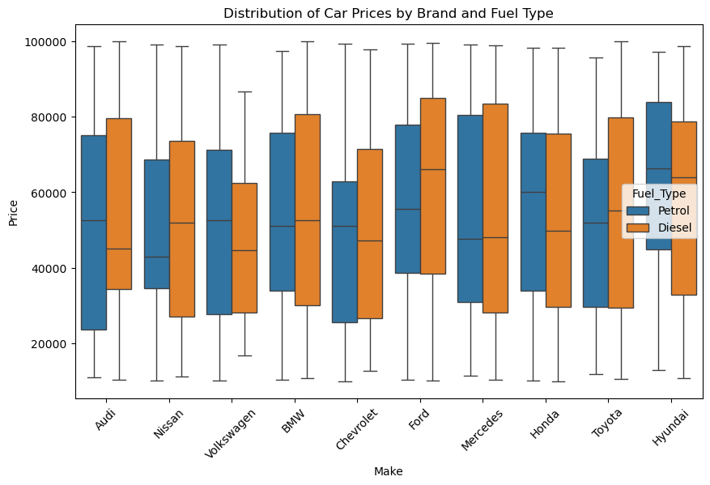

```python
# (i) Boxplot of car prices by brand & fuel type
import seaborn as sns
import matplotlib.pyplot as plt

plt.figure(figsize=(10,6))
sns.boxplot(x="Make", y="Price", hue="Fuel_Type", data=df)
plt.title("Distribution of Car Prices by Brand and Fuel Type")
plt.xticks(rotation=45)
plt.show()
```

Inference:

Shows spread of prices.

```python
# (ii) Average price per make excluding missing values
clean_df = df.dropna(subset=["Price","Mileage"])
avg_price_make = clean_df.groupby("Make")["Price"].mean()
print(avg_price_make)
```

```
Make
Audi          52472.989362
BMW           54302.551402
Chevrolet     49898.934579
Ford          58432.390909
Honda         53619.518072
Hyundai       60842.516484
Mercedes      52823.489583
Nissan        51360.670213
Toyota        52706.525424
Volkswagen    49136.260000
Name: Price, dtype: float64
```

Inference:

Ensures analysis is not biased by missing data.

```
Fuel_Type   Diesel  Petrol
Make
Audi            50      44
BMW             61      46
Chevrolet       50      57
Ford            54      56
Honda           41      42
Hyundai         48      43
Mercedes        43      53
Nissan          45      49
Toyota          70      48
Volkswagen      42      58
```

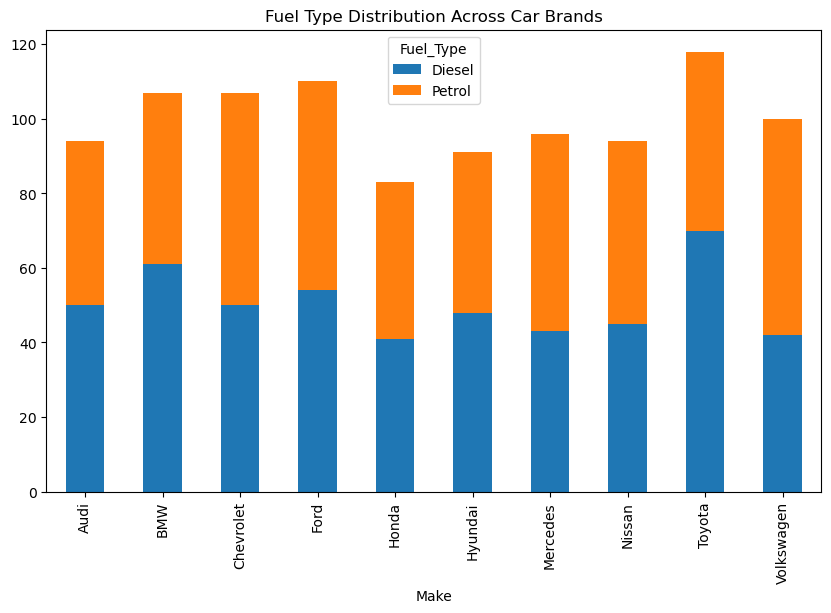

```python
# (iii) Fuel type distribution across brands
fuel_distribution = pd.crosstab(df["Make"], df["Fuel_Type"])
print(fuel_distribution)

fuel_distribution.plot(kind="bar", stacked=True, figsize=(10,6))
plt.title("Fuel Type Distribution Across Car Brands")
plt.show()
```

Inference:

Reveals which brands lean more towards Petrol or Diesel.

Helps dealership stock planning.

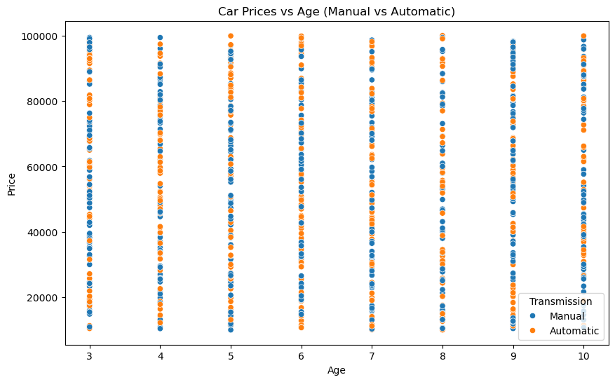

```python
# (iv) Car prices vs age, manual vs automatic
df["Age"] = 2025 - df["Year"]

plt.figure(figsize=(10,6))
sns.scatterplot(x="Age", y="Price", hue="Transmission", data=df)
plt.title("Car Prices vs Age (Manual vs Automatic)")
plt.show()
```

Inference:

Transmission type may affect depreciation differently.

```
Most listed make: Toyota
```

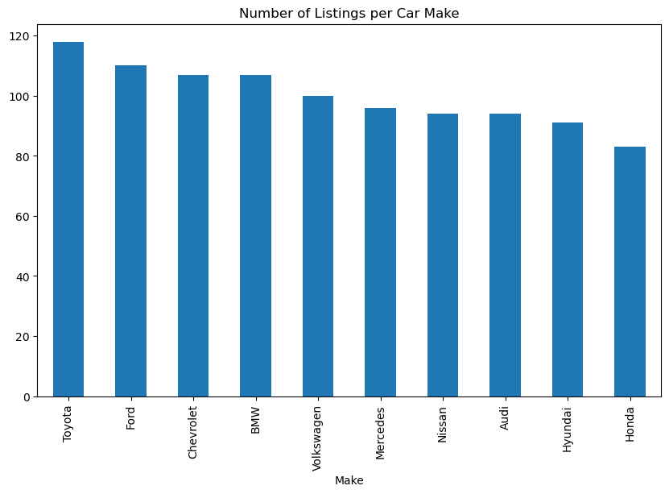

```python
# (v) Most listed car make
make_counts = df["Make"].value_counts()
print("Most listed make:", make_counts.idxmax())

make_counts.plot(kind="bar", figsize=(10,6))
plt.title("Number of Listings per Car Make")
plt.show()
```

Inference:

Identifies the most common brand in inventory.

Useful for dealership marketing focus.